# supermarket_sales

## Exploratory Data Analysis With Python and Pandas

[figure not shown]

### Libraries

```python
import warnings
warnings.filterwarnings('ignore')
```

```python
import pandas as pd
import numpy as np
import matplotlib.pyplot as plt
import seaborn as sns
import calmap
```

Link to data source: https://www.kaggle.com/aungpyaeap/supermarket-sales

**Context**

The growth of supermarkets in most populated cities are increasing and market competitions are also high. The dataset is one of the historical sales of supermarket company which has recorded in 3 different branches for 3 months data.

**Data Dictionary**

1. *Invoice id:* Computer generated sales slip invoice identification number
2. *Branch:* Branch of supercenter (3 branches are available identified by A, B and C).
3. *City:* Location of supercenters
4. *Customer type:* Type of customers, recorded by Members for customers using member card and Normal for without member card.
5. *Gender:* Gender type of customer
6. *Product line:* General item categorization groups - Electronic accessories, Fashion accessories, Food and beverages, Health and beauty, Home and lifestyle, Sports and travel
7. *Unit price:* Price of each product in USD
8. *Quantity:* Number of products purchased by customer
9. *Tax:* 5% tax fee for customer buying
10. *Total:* Total price including tax
11. *Date:* Date of purchase (Record available from January 2019 to March 2019)
12. *Time:* Purchase time (10am to 9pm)
13. *Payment:* Payment used by customer for purchase (3 methods are available – Cash, Credit card and Ewallet)
14. *COGS:* Cost of goods sold
15. *Gross margin percentage:* Gross margin percentage
16. *Gross income:* Gross income
17. *Rating:* Customer stratification rating on their overall shopping experience (On a scale of 1 to 10)

### Task 1: Initial Data Exploration

```python
df = pd.read_csv("C:\\Users\DALASH\Documents\data_analysis\projects\supermarket_sales\dataset\supermarket_sales_1.csv")
```

```python
df.head()
```

|  | Invoice ID | Branch | City | Customer type | Gender | Product line | Unit price | Quantity | Tax 5% | Total | Date | Time | Payment | cogs | gross margin percentage | gross income | Rating |
| --- | --- | --- | --- | --- | --- | --- | --- | --- | --- | --- | --- | --- | --- | --- | --- | --- | --- |
| 0 | 750-67-8428 | A | Yangon | Member | Female | Health and beauty | 74.69 | 7 | 26.1415 | 548.9715 | 1/5/2019 | 13:08 | Ewallet | 522.83 | 4.761905 | 26.1415 | 9.1 |
| 1 | 226-31-3081 | C | Naypyitaw | Normal | Female | Electronic accessories | 15.28 | 5 | 3.8200 | 80.2200 | 3/8/2019 | 10:29 | Cash | 76.40 | 4.761905 | 3.8200 | 9.6 |
| 2 | 631-41-3108 | A | Yangon | Normal | Male | Home and lifestyle | 46.33 | 7 | 16.2155 | 340.5255 | 3/3/2019 | 13:23 | Credit card | 324.31 | 4.761905 | 16.2155 | 7.4 |
| 3 | 123-19-1176 | A | Yangon | Member | Male | Health and beauty | 58.22 | 8 | 23.2880 | 489.0480 | 1/27/2019 | 20:33 | Ewallet | 465.76 | 4.761905 | 23.2880 | 8.4 |
| 4 | 373-73-7910 | A | Yangon | Normal | Male | Sports and travel | 86.31 | 7 | 30.2085 | 634.3785 | 2/8/2019 | 10:37 | Ewallet | 604.17 | 4.761905 | 30.2085 | 5.3 |

```python
df.columns
```

```
Index(['Invoice ID', 'Branch', 'City', 'Customer type', 'Gender',
       'Product line', 'Unit price', 'Quantity', 'Tax 5%', 'Total', 'Date',
       'Time', 'Payment', 'cogs', 'gross margin percentage', 'gross income',
       'Rating'],
      dtype='object')
```

```python
df.dtypes
```

```
Invoice ID                  object
Branch                      object
City                        object
Customer type               object
Gender                      object
Product line                object
Unit price                 float64
Quantity                     int64
Tax 5%                     float64
Total                      float64
Date                        object
Time                        object
Payment                     object
cogs                       float64
gross margin percentage    float64
gross income               float64
Rating                     float64
dtype: object
```

```python
df['Date'] = pd.to_datetime(df['Date'])
```

```python
df['Date']
```

```
0     2019-01-05
1     2019-03-08
2     2019-03-03
3     2019-01-27
4     2019-02-08
         ...
995   2019-01-29
996   2019-03-02
997   2019-02-09
998   2019-02-22
999   2019-02-18
Name: Date, Length: 1000, dtype: datetime64[ns]
```

```python
df.set_index('Date', inplace=True)
```

```python
df.describe()
```

|  | Unit price | Quantity | Tax 5% | Total | cogs | gross margin percentage | gross income | Rating |
| --- | --- | --- | --- | --- | --- | --- | --- | --- |
| count | 1000.000000 | 1000.000000 | 1000.000000 | 1000.000000 | 1000.00000 | 1.000000e+03 | 1000.000000 | 1000.00000 |
| mean | 55.672130 | 5.510000 | 15.379369 | 322.966749 | 307.58738 | 4.761905e+00 | 15.379369 | 6.97270 |
| std | 26.494628 | 2.923431 | 11.708825 | 245.885335 | 234.17651 | 6.131498e-14 | 11.708825 | 1.71858 |
| min | 10.080000 | 1.000000 | 0.508500 | 10.678500 | 10.17000 | 4.761905e+00 | 0.508500 | 4.00000 |
| 25% | 32.875000 | 3.000000 | 5.924875 | 124.422375 | 118.49750 | 4.761905e+00 | 5.924875 | 5.50000 |
| 50% | 55.230000 | 5.000000 | 12.088000 | 253.848000 | 241.76000 | 4.761905e+00 | 12.088000 | 7.00000 |
| 75% | 77.935000 | 8.000000 | 22.445250 | 471.350250 | 448.90500 | 4.761905e+00 | 22.445250 | 8.50000 |
| max | 99.960000 | 10.000000 | 49.650000 | 1042.650000 | 993.00000 | 4.761905e+00 | 49.650000 | 10.00000 |

### Task 2: Univariate Analysis

**Question 1:** What does the distribution of customer ratings looks like? Is it skewed?

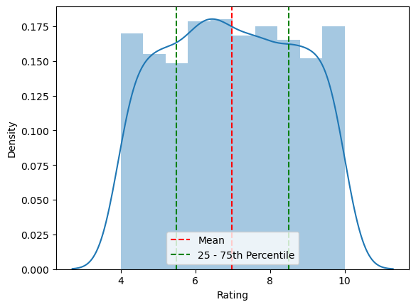

```python
sns.distplot(df['Rating'])
plt.axvline(x=np.mean(df['Rating']), c='red', ls='--', label= 'Mean')
plt.axvline(x=np.percentile(df['Rating'], 25), c='green', ls='--', label= '25 - 75th Percentile')
plt.axvline(x=np.percentile(df['Rating'], 75), c='green', ls='--')
plt.legend()
```

```
array([[<Axes: title={'center': 'Unit price'}>,
        <Axes: title={'center': 'Quantity'}>,
        <Axes: title={'center': 'Tax 5%'}>],
       [<Axes: title={'center': 'Total'}>,
        <Axes: title={'center': 'cogs'}>,
        <Axes: title={'center': 'gross margin percentage'}>],
       [<Axes: title={'center': 'gross income'}>,
        <Axes: title={'center': 'Rating'}>, <Axes: >]], dtype=object)
```

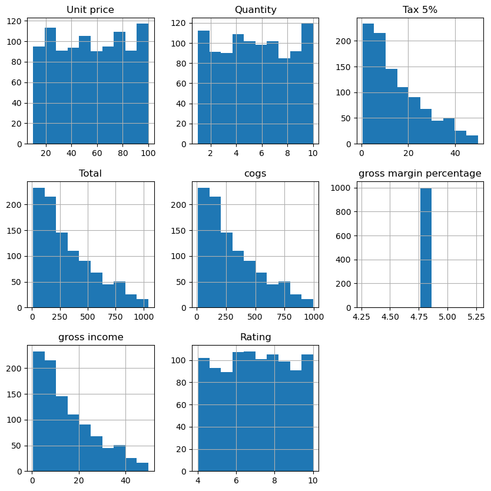

```python
df.hist(figsize= (10, 10))
```

**Question 2:** Do aggregate sales numbers differ by much between branches?

```python
df['Branch'].unique()
```

```
array(['A', 'C', 'B'], dtype=object)
```

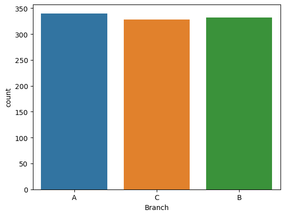

```python
sns.countplot(x='Branch', data=df)
```

```python
df['Branch'].value_counts()
```

```
A    340
B    332
C    328
Name: Branch, dtype: int64
```

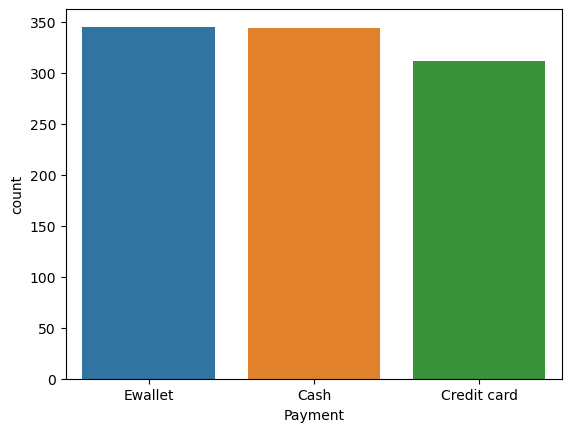

```python
sns.countplot(x='Payment', data=df)
```

### Task 3: Bivariate Analysis

**Question 3:** Is there a relationship between gross income and customer ratings?

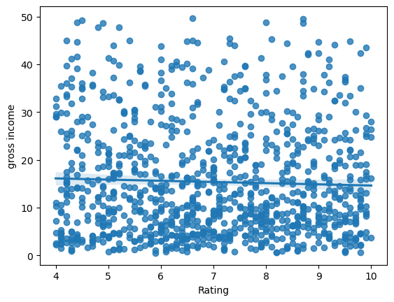

```python
sns.regplot(x='Rating', y='gross income', data=df)
```

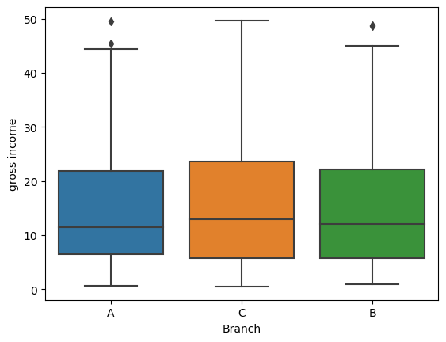

```python
sns.boxplot(x='Branch', y='gross income', data=df)
```

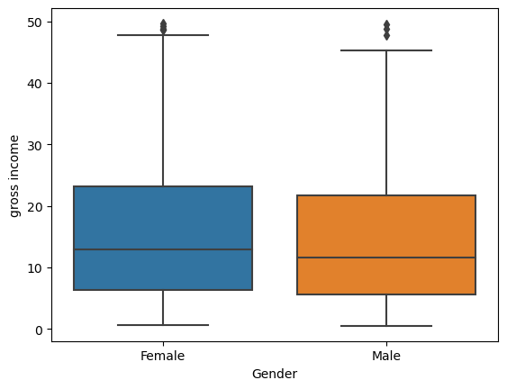

```python
sns.boxplot(x=df['Gender'], y= df['gross income'])
```

**Question 4:** Is there a noticeable time trend in gross income?

```python
df.groupby(df.index).mean().index
```

```
DatetimeIndex(['2019-01-01', '2019-01-02', '2019-01-03', '2019-01-04',
               '2019-01-05', '2019-01-06', '2019-01-07', '2019-01-08',
               '2019-01-09', '2019-01-10', '2019-01-11', '2019-01-12',
               '2019-01-13', '2019-01-14', '2019-01-15', '2019-01-16',
               '2019-01-17', '2019-01-18', '2019-01-19', '2019-01-20',
               '2019-01-21', '2019-01-22', '2019-01-23', '2019-01-24',
               '2019-01-25', '2019-01-26', '2019-01-27', '2019-01-28',
               '2019-01-29', '2019-01-30', '2019-01-31', '2019-02-01',
               '2019-02-02', '2019-02-03', '2019-02-04', '2019-02-05',
               '2019-02-06', '2019-02-07', '2019-02-08', '2019-02-09',
               '2019-02-10', '2019-02-11', '2019-02-12', '2019-02-13',
               '2019-02-14', '2019-02-15', '2019-02-16', '2019-02-17',
               '2019-02-18', '2019-02-19', '2019-02-20', '2019-02-21',
               '2019-02-22', '2019-02-23', '2019-02-24', '2019-02-25',
               '2019-02-26', '2019-02-27', '2019-02-28', '2019-03-01',
               '2019-03-02', '2019-03-03', '2019-03-04', '2019-03-05',
               '2019-03-06', '2019-03-07', '2019-03-08', '2019-03-09',
               '2019-03-10', '2019-03-11', '2019-03-12', '2019-03-13',
               '2019-03-14', '2019-03-15', '2019-03-16', '2019-03-17',
               '2019-03-18', '2019-03-19', '2019-03-20', '2019-03-21',
               '2019-03-22', '2019-03-23', '2019-03-24', '2019-03-25',
               '2019-03-26', '2019-03-27', '2019-03-28', '2019-03-29',
               '2019-03-30'],
              dtype='datetime64[ns]', name='Date', freq=None)
```

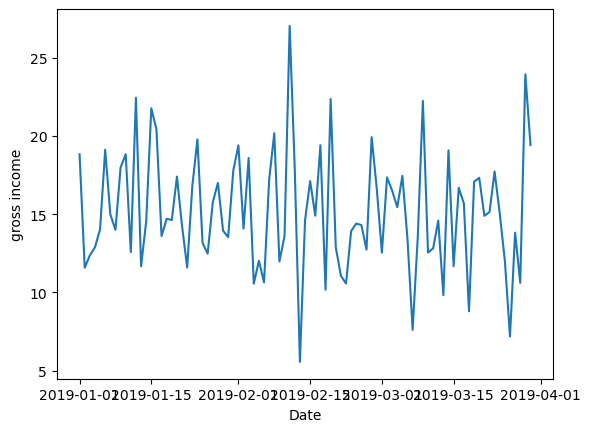

```python
sns.lineplot(x= df.groupby(df.index).mean().index, y= df.groupby(df.index).mean()['gross income'])
```

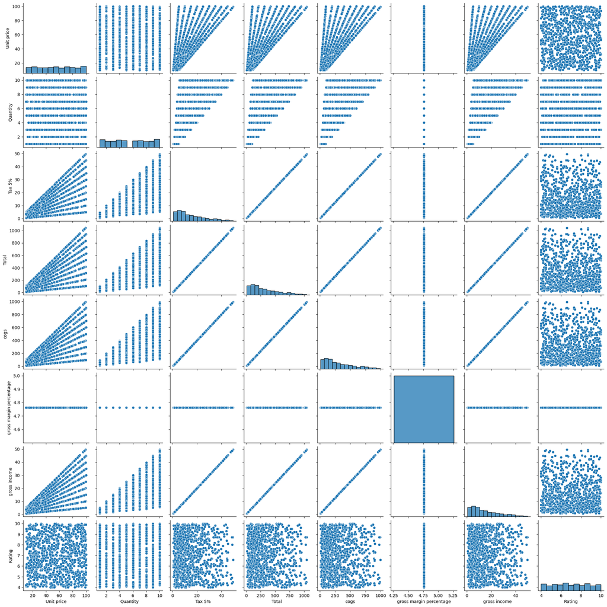

```python
sns.pairplot(df)
```

### Task 4: Dealing With Duplicate Rows and Missing Values

```python
df.duplicated().sum()
```

```
0
```

```python
df.isna().sum()
```

```
Invoice ID                 0
Branch                     0
City                       0
Customer type              0
Gender                     0
Product line               0
Unit price                 0
Quantity                   0
Tax 5%                     0
Total                      0
Time                       0
Payment                    0
cogs                       0
gross margin percentage    0
gross income               0
Rating                     0
dtype: int64
```

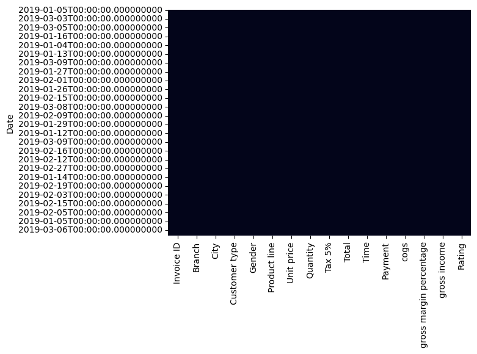

```python
sns.heatmap(df.isnull(), cbar = 0)
```

### Task 5: Correlation Analysis

```python
round(np.corrcoef(df['gross income'], df['Rating'])[1][0], 2)
```

```
-0.04
```

```python
np.round(df.corr(), 2)
```

|  | Unit price | Quantity | Tax 5% | Total | cogs | gross margin percentage | gross income | Rating |
| --- | --- | --- | --- | --- | --- | --- | --- | --- |
| Unit price | 1.00 | 0.01 | 0.63 | 0.63 | 0.63 | NaN | 0.63 | -0.01 |
| Quantity | 0.01 | 1.00 | 0.71 | 0.71 | 0.71 | NaN | 0.71 | -0.02 |
| Tax 5% | 0.63 | 0.71 | 1.00 | 1.00 | 1.00 | NaN | 1.00 | -0.04 |
| Total | 0.63 | 0.71 | 1.00 | 1.00 | 1.00 | NaN | 1.00 | -0.04 |
| cogs | 0.63 | 0.71 | 1.00 | 1.00 | 1.00 | NaN | 1.00 | -0.04 |
| gross margin percentage | NaN | NaN | NaN | NaN | NaN | NaN | NaN | NaN |
| gross income | 0.63 | 0.71 | 1.00 | 1.00 | 1.00 | NaN | 1.00 | -0.04 |
| Rating | -0.01 | -0.02 | -0.04 | -0.04 | -0.04 | NaN | -0.04 | 1.00 |

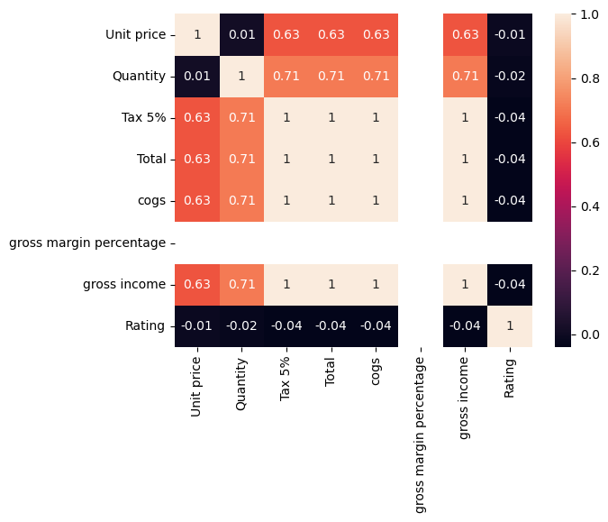

```python
sns.heatmap(np.round(df.corr(), 2), annot= True)
```